# Wyjaśnialne Uczenie Maszynowe - Praca domowa 4

Większa wartość zmiennej odpowiadającej średniej powierzchni użytkowej dla 15 najbliższych sąsiadów (`sqft_living15`) zwiększa predykcję ceny nieruchomości.

Ostatnią zmienną ciągłą w modelu jest wiek nieruchomości (`year`), gdyby nasz dom być nieco starszy jego cena mogłaby wzrosnąć, jednocześnie nieruchomości o mniejszym wieku byłyby tańsze.

Dodatkowo w modelu mamy dwie zmienne kategoryczne: czy jest widok na wodę (`waterfront`) - zmienna binarna oraz kod pocztowy (`zipcode`) przyjmujący 70 wartości.

Jeżeli nasza nieruchomośc miałaby widok na wodę wtedy cena znacząco wzrasta, około 1.5 raza.

Patrząc na profil Ceteris Paribus dla zmiennej kod pocztowy możemy zauważyć, że jeśli nieruchmość byłby wybudowana w innym położeniu, cena mogłaby wzrosnąć nawet 1.5 raza. Istnieje kilka lokalizacji, w których cena mogłaby zmaleć, jednak przeważa liczba kodów pocztowych, w których cena będzie wyższa.

W celu poszukania obserwacji dla których profile Ceteris Paribus będą różne wybrano losowo 200 obserwacji i wyrysowano profile. Dodatkowo narysowano PDP (Partial Dependency Plot).

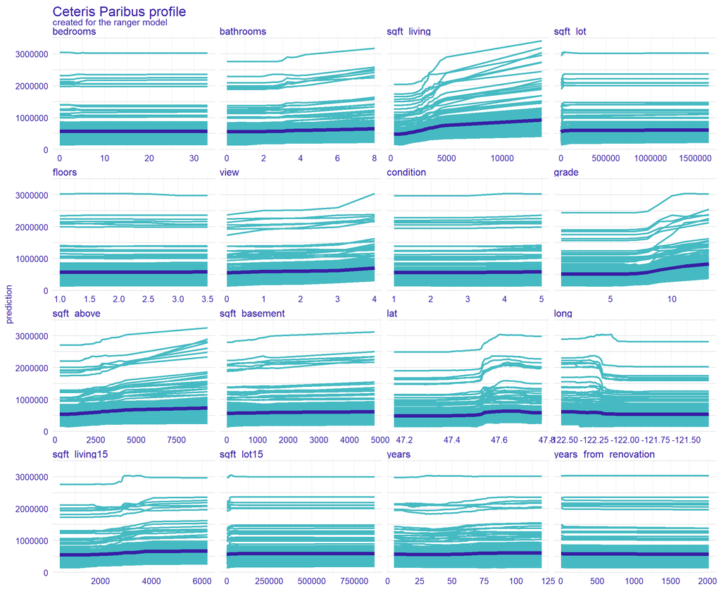

W modelu lasu losowego nie zauważono interakcji, być może model jest addytywny. W tym celu zbudowano kolejny model, tym razem jest to gradient boosting machine (gbm). (Ad 4)

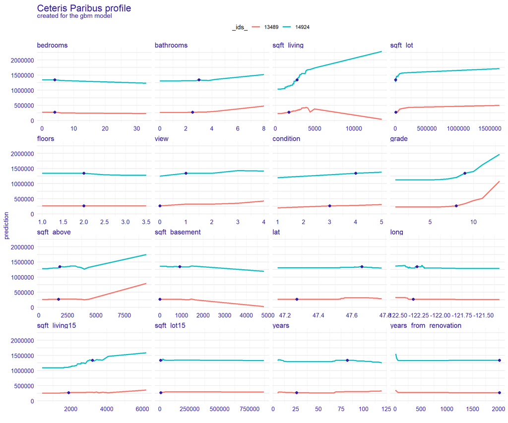

Na podstawie powyższych profili Ceteris Paribus dla dwóch wybranych obserwacji możemy zaobserwować, że dla zmiennej `sqft_living` się różnią. Dla obserwacji `14924` zwiększenie powierzchni mieszkalnej powoduje zwiększenie predykcji ceny mieszkania, natomiast dla obserwacji `13489` wraz ze wzrostem powierzchni użytkowej na początku delikatnie rośnie, a następnie maleje. Ten związek może być spowodowany interakcją w modelu, na przykład ze zmienną `sqft_basement`.